# Predicting the form of barbell lift

## Synopsis

Applications of human activity recognition is escalating over the past few years which often estimate the quantity of work done. The experimental data used in this project aims to predict the quality of barbell lifts performed in 5 different ways only one of which is precise. Data is collected from the accelerometers attached to the belt,arm,forearm and dumbbell of each participant. Predictions using random forest algorithm gives an accuracy of **99.78%** and estimated out of sample error rate of **0.25%**

### Loading Data

```r
library(caret)
library(randomForest)
```

```r
traindata <- read.csv("pml-training.csv")
testfinal <- read.csv("pml-testing.csv")
dim <- as.data.frame(rbind("traindata"=dim(traindata),"testfinal"=dim(testfinal)))
names(dim) <- c("rows","columns")
dim
```

```
##            rows columns
## traindata 19622     160
## testfinal    20     160
```

### Cleaning Data

The complete dataset, *traindata* and the final testset, *testfinal* have **160** variables few of which can be eliminated for our analysis for various reasons. Firstly, there are few index variables( *columns 1 to 5* ) and there are several other variables which have lots of NA’s(*nacols* ). These variables are removed to obtain a clean dataset, **trainingdata**. Corresponding changes are even made to the final test dataset. The numnber of variables considerably diminished to 88

```r
      traindata <- traindata[,-c(1,2,3,4,5)]
      testfinal <- testfinal[,-c(1,2,3,4,5)]
#Removing NA's
      nacols <- c(NULL)
        for(i in 1:length(traindata)) nacols[i] <- sum(is.na(traindata[,i]))>5000
          trainingdata <- traindata[!nacols]
          testfinal <- testfinal[!nacols]
          dim <- rbind(dim,trainingdata=dim(trainingdata))
          dim
```

```
##               rows columns
## traindata    19622     160
## testfinal       20     160
## trainingdata 19622      88
```

### Splitting Data

As our final test set has only 20 samples, we need to build training(75%) and test datasets(25%) from the clean *trainingdata* for the sake of cross validation.Any preprocessing is to be done on the new *training* dataset on which are about to build a model.

```r
set.seed(1234)
inTrain <- createDataPartition(trainingdata$classe,p=0.75,list=FALSE)
train <- trainingdata[inTrain,]
test <- trainingdata[-inTrain,]
```

### Check for highly correlated variables

Even though our data is now ready for modeling, a more efficient way is to check for ineffective variables. First, the variables with variances close to zero are removed using *nearZeroVar()* function and then the rest of the variables are checked for redundancy. It is observed that three variables are highly correlated() and are removed using *findCorrelation()* function.

```r
set.seed(1234)
nearZeroVars <- nearZeroVar(train,saveMetrics=TRUE)
training_NZ <- train[!nearZeroVars$nzv]
testing_NZ <- test[!nearZeroVars$nzv]
testfinal <- testfinal[!nearZeroVars$nzv]

set.seed(2345)
highCorr <- findCorrelation(cor(training_NZ[,-length(training_NZ)]))
training <- training_NZ[,-highCorr]
testing <- testing_NZ[,-highCorr]
testfinal <- testfinal[,-highCorr]
dim <- rbind(dim,"training"=dim(training),
             "testing"=dim(testing),"testfinal"=dim(testfinal))
dim
```

```
##               rows columns
## traindata    19622     160
## testfinal       20     160
## trainingdata 19622      88
## training     14718      47
## testing       4904      47
## testfinal1      20      47
```

### Transformations

It is also important that all the variables have similar class for a faster computation. Our variables are a mixture of integers and numeric classes and hence all of them,except Classe, are converted to numeric.

```r
a <- length(training)-1
          for(i in 1:a) {
              training[,i] <- as.numeric(training[,i])
              testing[,i] <- as.numeric(testing[,i])
              testfinal[,i] <- as.numeric(testfinal[,i])
          }
```

### Fitting a model

A random forest algorithm is used on the *training* data to build our model and the predictions are made on the *testing* data. The cross validation resulted in a good accuracy of 99.78%, which means that the out of sample error rate(OOB) of the model is **0.25%**. The model has 500 trees with 6 variables tried at each split.

```r
mod1 <- randomForest(classe~.,data=training)
pred <- predict(mod1,testing,type="class")
mod1
```

```
##
## Call:
##  randomForest(formula = classe ~ ., data = training)
##                Type of random forest: classification
##                      Number of trees: 500
## No. of variables tried at each split: 6
##
##         OOB estimate of  error rate: 0.25%
## Confusion matrix:
##      A    B    C    D    E  class.error
## A 4184    0    0    0    1 0.0002389486
## B    4 2842    2    0    0 0.0021067416
## C    0   10 2556    1    0 0.0042851578
## D    0    0   13 2398    1 0.0058043118
## E    0    0    0    5 2701 0.0018477458
```

### Cross Validation

```r
confusionMatrix(pred,testing$classe)
```

```
## Confusion Matrix and Statistics
##
##           Reference
## Prediction    A    B    C    D    E
##          A 1395    1    0    0    0
##          B    0  947    5    0    0
##          C    0    1  850    4    0
##          D    0    0    0  800    0
##          E    0    0    0    0  901
##
## Overall Statistics
##
##                Accuracy : 0.9978
##                  95% CI : (0.996, 0.9989)
##     No Information Rate : 0.2845
##     P-Value [Acc > NIR] : < 2.2e-16
##
##                   Kappa : 0.9972
##  Mcnemar's Test P-Value : NA
##
## Statistics by Class:
##
##                      Class: A Class: B Class: C Class: D Class: E
## Sensitivity            1.0000   0.9979   0.9942   0.9950   1.0000
## Specificity            0.9997   0.9987   0.9988   1.0000   1.0000
## Pos Pred Value         0.9993   0.9947   0.9942   1.0000   1.0000
## Neg Pred Value         1.0000   0.9995   0.9988   0.9990   1.0000
## Prevalence             0.2845   0.1935   0.1743   0.1639   0.1837
## Detection Rate         0.2845   0.1931   0.1733   0.1631   0.1837
## Detection Prevalence   0.2847   0.1941   0.1743   0.1631   0.1837
## Balanced Accuracy      0.9999   0.9983   0.9965   0.9975   1.0000
```

### Predicting the final test data

```r
predictions <- predict(mod1,testfinal,type="class")
answers <- as.character(predictions)
predictions
```

```
##  1  2  3  4  5  6  7  8  9 10 11 12 13 14 15 16 17 18 19 20
##  B  A  B  A  A  E  D  B  A  A  B  C  B  A  E  E  A  B  B  B
## Levels: A B C D E
```

## Plotting Percentage of Predictions

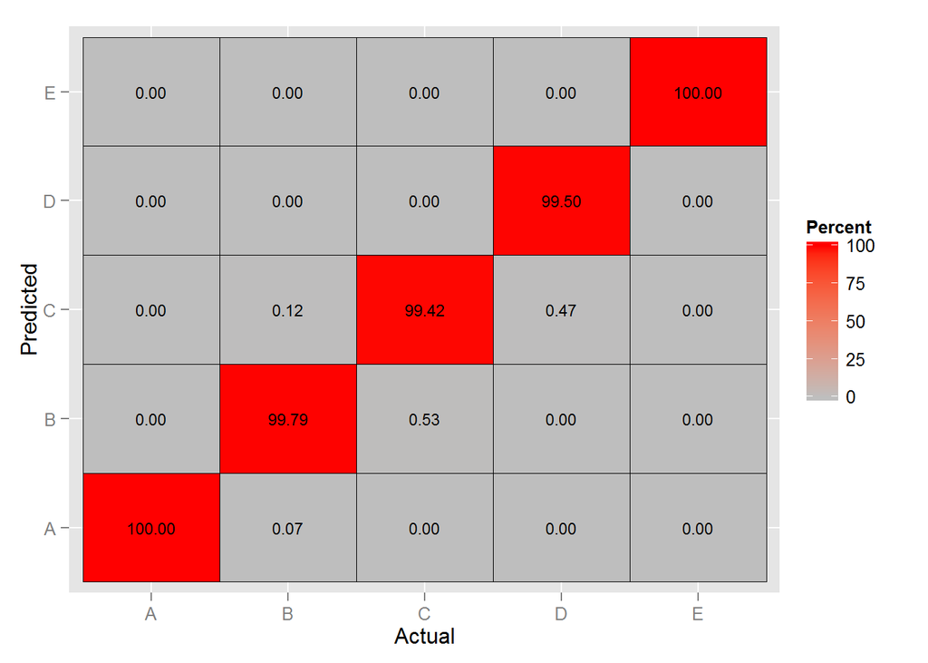

```r
actual = as.data.frame(table(testing$classe))
names(actual) = c("Actual","ActualFreq")

predicted <- as.data.frame(table("Predicted"=pred,"Actual"=testing$classe))
confusion = cbind(predicted, actual)
confusion$Percent = confusion$Freq/confusion$ActualFreq*100

## Plotting Heatmap
tile <- ggplot() +
  geom_tile(aes(x=Actual, y=Predicted,fill=Percent),data=confusion,
            color="black",size=0.1) +labs(x="Actual",y="Predicted")
tile = tile + geom_text(aes(x=Actual,y=Predicted,
              label=sprintf("%.2f", Percent)), data=confusion, size=3,
              colour="black") + scale_fill_gradient(low="grey",high="red")

tile = tile + geom_tile(aes(x=Actual,y=Predicted),
              data=subset(confusion, as.character(Actual)==as.character(Predicted)), color="black",size=0.3, fill="black", alpha=0)
tile
```

## Appendix

Source:

- The data deployed in the analysis is obtained from the Weight Lifting Exercise data provided in the paper by Velloso, E.; Bulling, A.; Gellersen, H.; Ugulino, W.; Fuks, H. Qualitative Activity Recognition of Weight Lifting Exercises. Proceedings of 4th International Conference in Cooperation with SIGCHI (Augmented Human ’13) . Stuttgart, Germany: ACM SIGCHI, 2013.

Classes of exercises(Output):

- Class A: Exactly according to the specification
- Class B: Throwing the elbows to the front
- Class C: Lifting the dumbbell only halfway
- Class D: Lowering the dumbbell only halfway
- Class E: Throwing the hips to the front